# Final Project: Guidance Document

Wenyu Yang

Due December 17, 2019

# Purpose

The research question that motivates the overall analysis: “Whether different gender has different performance on the math, reading, and writing exam? Which gender performs better on the overall academic performance?”

# Set Up

```r
# clean up the RSrudio environment
rm(list = ls())
# load necessary packages
library(datasets)
library(DataComputing)
library(tidyverse)
```

# Data Access

The data1 is the primary source, and the data2 is the secondary source which loaded from an R package “datasets”. I inspect the data by using the the head() and data.frame() functions to show the data tables.

```r
# import and inspect the first data source
data1 = read.csv("StudentsPerformance.csv")
head(data1)
```

|  | gender | race.ethnicity | parental.level.of.education | lunch | test.preparation.course | math.score | reading.score | writing.score |
| --- | --- | --- | --- | --- | --- | --- | --- | --- |
| 1 | female | group B | bachelor's degree | standard | none | 72 | 72 | 74 |
| 2 | female | group C | some college | standard | completed | 69 | 90 | 88 |
| 3 | female | group B | master's degree | standard | none | 90 | 95 | 93 |
| 4 | male | group A | associate's degree | free/reduced | none | 47 | 57 | 44 |
| 5 | male | group C | some college | standard | none | 76 | 78 | 75 |
| 6 | female | group B | associate's degree | standard | none | 71 | 83 | 78 |

```r
# import and inspect the second data source
data2<- UCBAdmissions
data.frame(data2)
```

| Admit | Gender | Dept | Freq |
| --- | --- | --- | --- |
| Admitted | Male | A | 512 |
| Rejected | Male | A | 313 |
| Admitted | Female | A | 89 |
| Rejected | Female | A | 19 |
| Admitted | Male | B | 353 |
| Rejected | Male | B | 207 |
| Admitted | Female | B | 17 |
| Rejected | Female | B | 8 |
| Admitted | Male | C | 120 |
| Rejected | Male | C | 205 |

[output cut: 14 more lines]

# Data Wrangling

Assign a new dataset newdata1 with adding a new variable total.score by mutate() function

```r
newdata1 <-
  data1 %>%
  mutate(total.score = math.score+reading.score+writing.score) %>%
  select(gender, math.score, reading.score, writing.score, total.score)
newdata1
```

| gender | math.score | reading.score | writing.score | total.score |
| --- | --- | --- | --- | --- |
| female | 72 | 72 | 74 | 218 |
| female | 69 | 90 | 88 | 247 |
| female | 90 | 95 | 93 | 278 |
| male | 47 | 57 | 44 | 148 |
| male | 76 | 78 | 75 | 229 |
| female | 71 | 83 | 78 | 232 |
| female | 88 | 95 | 92 | 275 |
| male | 40 | 43 | 39 | 122 |
| male | 64 | 64 | 67 | 195 |
| female | 38 | 60 | 50 | 148 |

[output cut: 990 more lines]

```r
data2 <- data.frame(data2)
newdata2 <-
  data2 %>%
  mutate(Gender=tolower(Gender)) %>%
  group_by(Admit, Gender) %>%
  summarise(total=sum(Freq)) %>%
  spread(key=Admit, value=total, fill=0) %>%
  group_by(Gender) %>%
  mutate(total=sum(Admitted+Rejected),
         admit.rate=total/Admitted)
newdata2
```

| Gender | Admitted | Rejected | total | admit.rate |
| --- | --- | --- | --- | --- |
| female | 557 | 1278 | 1835 | 3.294434 |
| male | 1198 | 1493 | 2691 | 2.246244 |

Performance is produced by joining newdata1 to newdata2. I will use this Performance for the later Data Visualization.

```r
Performance <-
  newdata1 %>%
  left_join(newdata2 %>% select(Gender,admit.rate),
            by=c("gender"="Gender"))
Performance
```

| gender | math.score | reading.score | writing.score | total.score | admit.rate |
| --- | --- | --- | --- | --- | --- |
| female | 72 | 72 | 74 | 218 | 3.294434 |
| female | 69 | 90 | 88 | 247 | 3.294434 |
| female | 90 | 95 | 93 | 278 | 3.294434 |
| male | 47 | 57 | 44 | 148 | 2.246244 |
| male | 76 | 78 | 75 | 229 | 2.246244 |
| female | 71 | 83 | 78 | 232 | 3.294434 |
| female | 88 | 95 | 92 | 275 | 3.294434 |
| male | 40 | 43 | 39 | 122 | 2.246244 |
| male | 64 | 64 | 67 | 195 | 2.246244 |
| female | 38 | 60 | 50 | 148 | 3.294434 |

[output cut: 990 more lines]

# Data Visualization

This scatterplot shows that in the math exam, male tends to perform better than female. It also shows that female tends to have larger variance since there are outliers at the lower left of the graph. In order to view the result and differences more clearly, I use two different colors for each gender. The red color demonstrate female, and the blue color demonstrate male.

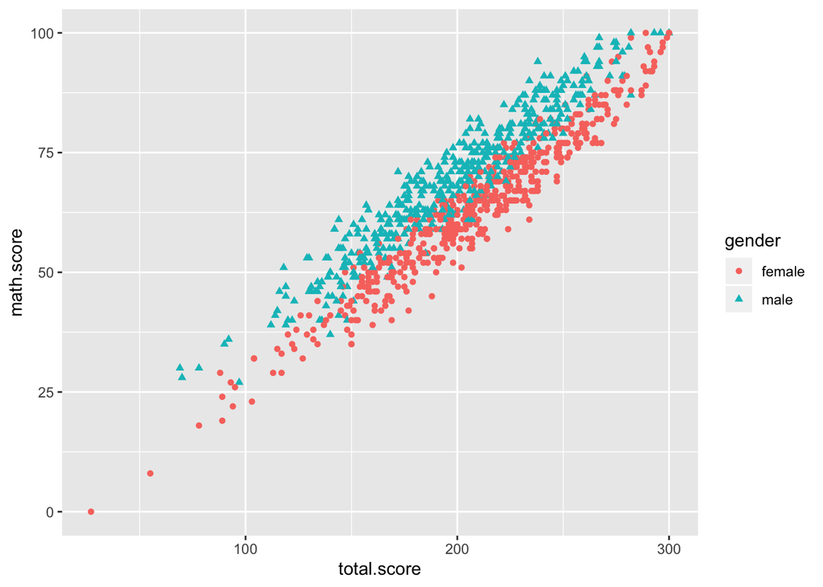

```r
Performance %>%
  ggplot(aes(x=total.score,y=math.score)) +
  geom_point(aes(shape=gender,color=gender))
```

This scatterplot shows that in the reading exam, female tends to perform better than male It also shows that female tends to have larger variance since there are outliers at the lower left of the graph. In order to view the result and differences more clearly, I use two different colors for each gender. The red color demonstrate female, and the blue color demonstrate male.

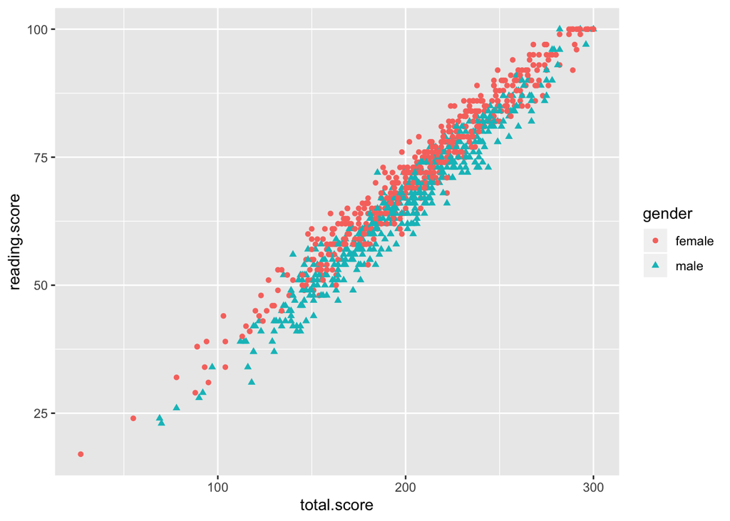

```r
Performance %>%
  ggplot(aes(x=total.score,y=reading.score)) +
  geom_point(aes(shape=gender, color=gender))
```

This plot shows that in the writing exam, female tends to perform better than male It also shows that female tends to have larger variance since there are outliers at the lower left of the graph. In order to view the result and differences more clearly, I use two different colors for each gender. The red color demonstrate female, and the blue color demonstrate male.

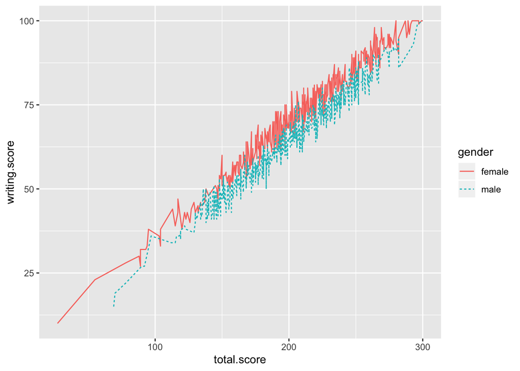

```r
Performance %>%
  ggplot(aes(x=total.score,y=writing.score)) +
  geom_line(aes(linetype=gender,color=gender))
```

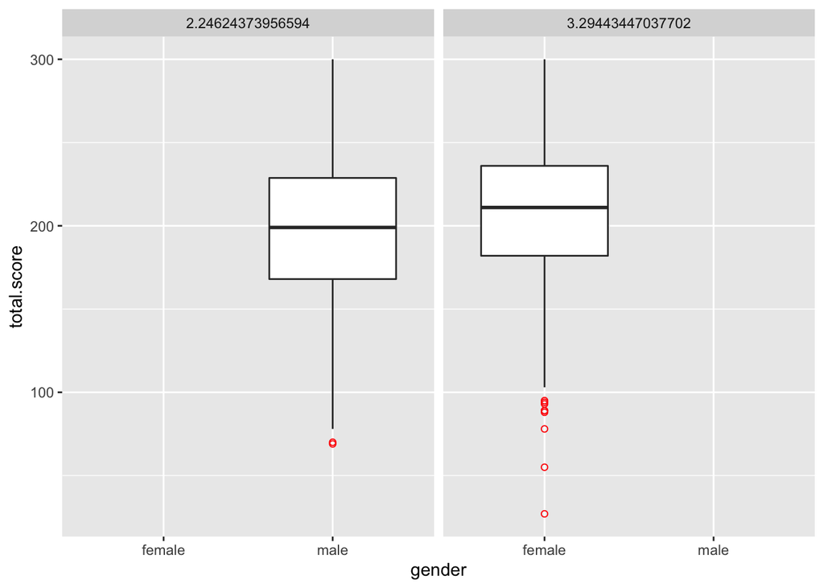

```r
Performance %>%
  ggplot(aes(x=gender,y=total.score)) +
  geom_boxplot(outlier.colour = "red", outlier.shape = 1) +
  facet_wrap(~ admit.rate)
```

The plot displays the distribution density of total.score for female and male. The red shading area demonstrates the density of total.score for female, and the blue shading area demonstrates the density of total.score for male. The plots shows that female tends to perform exam better than male. Female has higher density as the total.score increases than male.

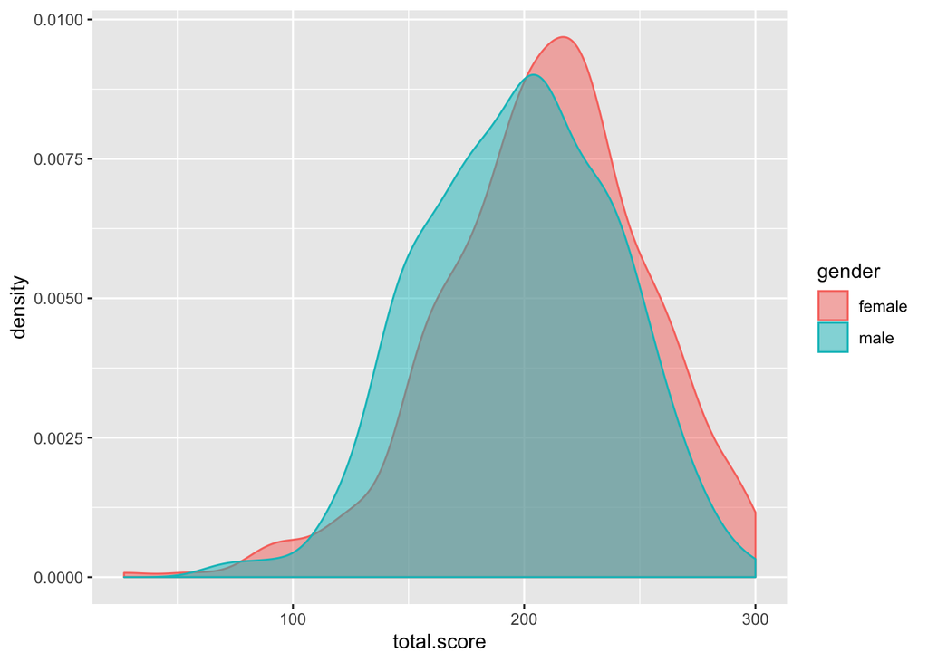

```r
ggplot(Performance, aes(x=total.score, group=gender)) +
  geom_density(aes(color=gender, fill=gender), alpha=0.5)
```

# Conclusion